# RegressionLineaire

Xavier Bouteiller

March 27, 2020

# Needed packages

```r
library(ggplot2)
library(dplyr)
library(broom)
```

# Exercice 1 : Chenille et taux de tanin dans les feuilles

## Charger les données

```r
DATAs0 <-read.table("./data/DATAcater.csv",
                    header=TRUE, sep=";", dec=",")

head(DATAs0)
str(DATAs0)
```

````
```
##        TANIN CROISSANCE
## 1  1.0404137     63.953
## 2 12.2666280     36.223
## 3 14.1393260     45.400
## 4  4.0407281     60.326
## 5  2.5402218     49.666
## 6  0.5084343     61.157
```

```
## 'data.frame':    84 obs. of  2 variables:
##  $ TANIN     : num  1.04 12.27 14.14 4.04 2.54 ...
##  $ CROISSANCE: num  64 36.2 45.4 60.3 49.7 ...
```
````

## Figures

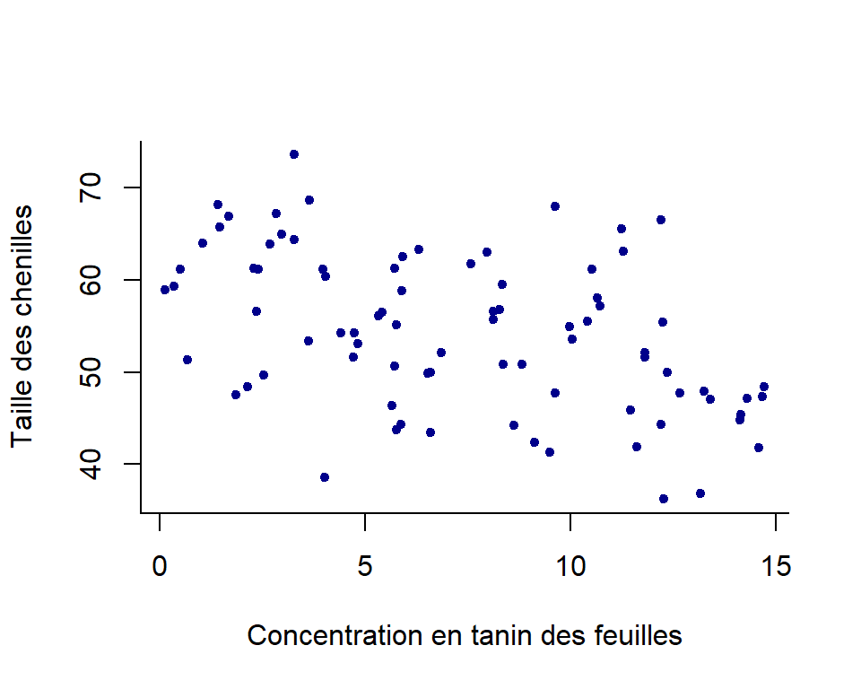

```r
plot(DATAs0$CROISSANCE~DATAs0$TANIN,
      bty = "l", # type de cadre
      pch= 20, # type de point
      col="darkblue", # couleur des points
      xlab="Concentration en tanin des feuilles", # titre de x
      ylab="Taille des chenilles")
```

## Démarche statistiques

1. Question bio
2. Hypothèses
3. Choix du test
4. Réalisation du test & validation
5. Conclusion

## 1. Question bio

Existe-t-il une relation entre la taille des chenilles et la concentration en tanin des feuilles?

## 2. Hypothèses

H0 : pas de relation linéaire entre X et Y

$$y_{i} = \beta_{0} + \epsilon_{i}$$

H1 : il existe une relation entre X et Y

$$y_{i} = \beta_{0} + \beta_{1} \times X_{i} + \epsilon_{i}$$

## 3. Choix du test

**regression lineaire**: 2 variables **quantitatives** continues

## 4. Réalisation du test & validation

### Realisation du modele

le modele lineaire peut être fait avec la fonction *aov()* ou *lm()*

```r
lm1 <- lm(CROISSANCE~TANIN, data = DATAs0)
```

```r
lm1_bis <- aov(CROISSANCE~TANIN, data = DATAs0)
```

Résultat identique, des différences dans la manipulation des objets créés

## validation

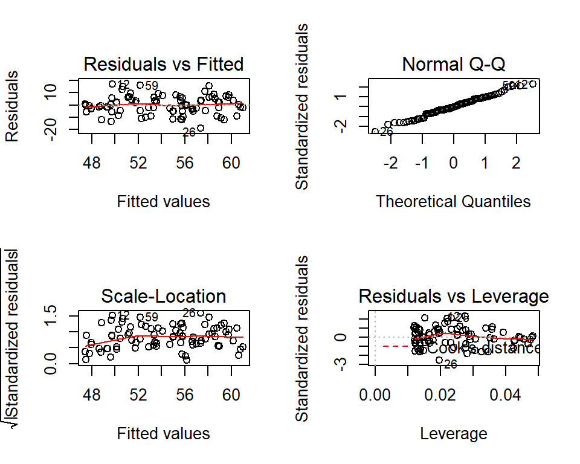

```r
par(mfrow=c(2,2))
plot(lm1)
```

## Interpretation

Interpretation **ssi** le modèle est valide

```r
knitr::kable(broom::tidy(summary(lm1)))
```

| term | estimate | std.error | statistic | p.value |
| --- | --- | --- | --- | --- |
| (Intercept) | 61.1302744 | 1.6462521 | 37.132998 | 0.0e+00 |
| TANIN | -0.9327825 | 0.1938953 | -4.810754 | 6.7e-06 |

```r
knitr::kable(broom::tidy(anova(lm1)))
```

| term | df | sumsq | meansq | statistic | p.value |
| --- | --- | --- | --- | --- | --- |
| TANIN | 1 | 1283.018 | 1283.01790 | 23.14335 | 6.7e-06 |
| Residuals | 82 | 4545.905 | 55.43786 | NA | NA |

## 5. Conclusion

Il existe un lien entre y (*croissance des chenilles*) et x(*concntration en tanin*) $\rightarrow$ un au moins des $\beta_{1}$ est différent de 0

L’équation de la droite de régression est :

$$y_{i} = 61.13 -0.93 \times X_{i} + \epsilon_{i}$$

Le coeff de la pente de régression est

$\beta_{1}$=-0.932782

Le signe est négatif, donc plus le taux de tanin $\nearrow$, plus la taille des chenilles $\searrow$

## 6. Extraire les coefficients estimés

```r
## intercept & slope
coef(lm1)
```

```
## (Intercept)       TANIN
##  61.1302744  -0.9327825
```

## 7. Fitted values?

### fonction fitted()

```r
## chaque observation a comme fitted values la 'moyenne' de son groupe
knitr::kable(fitted(lm1)[1:10])
```

| x |
| --- |
| 60.15979 |
| 49.68818 |
| 47.94136 |
| 57.36115 |
| 58.76080 |
| 60.65602 |
| 58.62876 |
| 52.15226 |
| 60.81018 |
| 61.01380 |

Les fitted values correspondent aux valeurs prédites par le modèle, soit pour une valeur X donnée, Y la valeur prédite

$$y = 61.13 -0.93 \times X$$
Notez l’absence du résidus $\epsilon$

ex: si le taux de tanin est 5, la valeur prédite par le modèle pour la taille des chenilles est:

$$y = 61.13 -0.93 \times 5 = 56.48$$

## 8. Bonus: Retrouvons le résultat manuellement

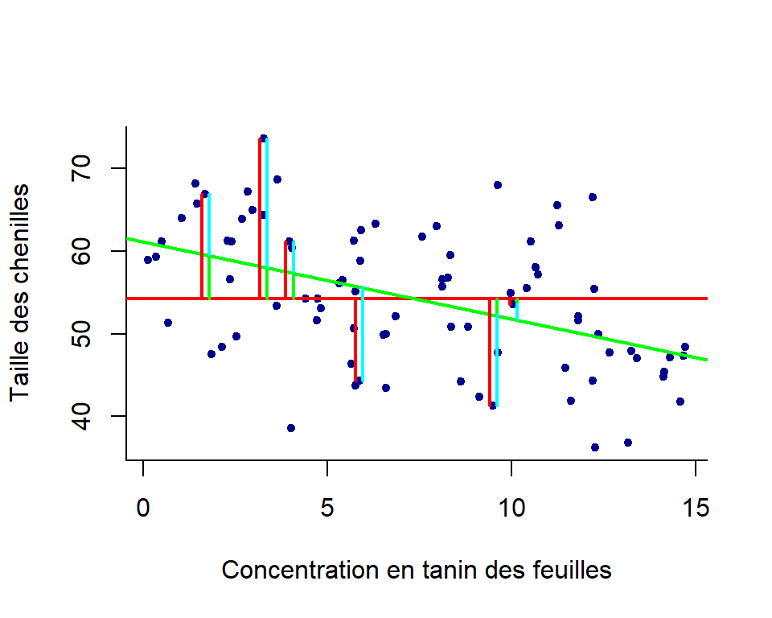

```r
par(mfrow = c(1,1))

plot(DATAs0$CROISSANCE~DATAs0$TANIN,
       bty = "l", # type de cadre
       pch= 20, # type de point
       col="darkblue", # couleur des points
       xlab="Concentration en tanin des feuilles", # titre de x
       ylab="Taille des chenilles") # titre de y

#moyenne generale = modele nul
abline(h=mean(DATAs0$CROISSANCE), col = 'red', lwd = 2)

#droite ajustee
abline(lm1, col = 'green', lwd = 2)

# pour une point (ex le point 15)

point_to_print= 15
point_to_print= c(15,20,25,30,35,40)

#var totale
segments(x0= DATAs0$TANIN[point_to_print]-0.1 , y0= DATAs0$CROISSANCE[point_to_print],
         x1= DATAs0$TANIN[point_to_print]-0.1 , y1 = mean(DATAs0$CROISSANCE) , lwd = 2,  col = 'red')


#var expliquée
segments(x0= DATAs0$TANIN[point_to_print]+0.1 , y0= lm1$fitted.values[point_to_print],
         x1= DATAs0$TANIN[point_to_print]+0.1 , y1 = mean(DATAs0$CROISSANCE) , lwd = 2,  col = 'green')

#var résiduelle
segments(x0= DATAs0$TANIN[point_to_print]+0.1 , y0=  DATAs0$CROISSANCE[point_to_print],
         x1= DATAs0$TANIN[point_to_print]+0.1 , y1 = lm1$fitted.values[point_to_print] , lwd = 2,  col = 'cyan')
```

## Variance totale, expliquée et résiduelle

```r
    #variation totale (ici en rouge)

SCET <- sum((DATAs0$CROISSANCE - mean(DATAs0$CROISSANCE))^2) ; SCET
```

```
## [1] 5828.923
```

```r
  #variation expliquée
SCER <- sum((lm1$fitted.values - mean(DATAs0$CROISSANCE))^2) ; SCER
```

```
## [1] 1283.018
```

```r
  #Variation residuelle
SCEE <- sum((lm1$fitted.values - DATAs0$CROISSANCE)^2);  SCEE
```

```
## [1] 4545.905
```

```r
knitr::kable(broom::tidy(anova(lm1)))
```

| term | df | sumsq | meansq | statistic | p.value |
| --- | --- | --- | --- | --- | --- |
| TANIN | 1 | 1283.018 | 1283.01790 | 23.14335 | 6.7e-06 |
| Residuals | 82 | 4545.905 | 55.43786 | NA | NA |

## Test de Fisher: F statistic

F calculée

```r
Fcalc = (SCER/1) / (SCEE /(nrow(DATAs0)-2)) ; Fcalc
```

```
## [1] 23.14335
```

```r
Fcrit = qf(0.95,df1=1,df2=82)
Fcrit
```

```
## [1] 3.957388
```

Fcalc > Fcrit $\rightarrow$ pvalue < 0.05 (seuil prédéfini)

# Exercice 2: comprendre la significativité des coefficients et l’intensité d’une relation

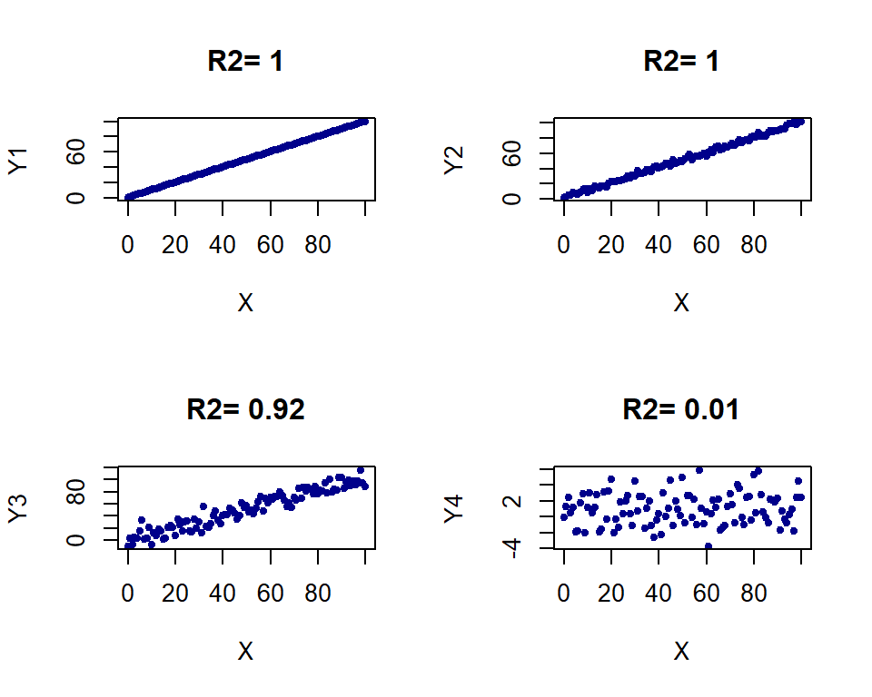

```r
X = seq (0,100, by = 1)
Y1 = X
Y2 = X + rnorm(n = length(X), mean = 1 , sd = 2)
Y3 = X + rnorm(n = length(X), mean = 1 , sd = 10)
Y4 = rnorm(n =length(X), mean = 1 , sd = 2)

lm1 <- lm(Y1 ~ X)
lm2 <- lm(Y2 ~ X)
lm3 <- lm(Y3 ~ X)
lm4 <- lm(Y4 ~ X)

par(mfrow= c(2,2))
plot(Y1 ~ X, pch= 20,col="darkblue",
     main=paste('R2=', round(summary(lm1)$r.squared,2)))
plot(Y2 ~ X, pch= 20, col="darkblue",
     main=paste('R2=', round(summary(lm2)$r.squared,2)))
plot(Y3 ~ X, pch= 20, col="darkblue",
     main=paste('R2=', round(summary(lm3)$r.squared,2)))
plot(Y4 ~ X, pch= 20, col="darkblue",
     main=paste('R2=', round(summary(lm4)$r.squared,2)))
```

# A vous de jouer

## Tableau de données « meteo.csv ».

Question 1 :

- 1. existe-il une relation entre la température annuelle moyenne (Temperature_an, variable dépendante) et la latitude (Latitude, variable indépendante) ?
- 2. Tracer sur le graphique la droite ajustée par la régression linéaire (si la relation est significative)
- 3. Que vaut le coefficient R² ?

Question 2 :

- 1. existe-il une relation entre la précipitation annuelle moyenne (Precipitations, variable dépendante) et la latitude (Latitude, variable indépendante) ?
- 2. Tracer sur le graphique la droite ajustée par la régression linéaire (si la relation est significative)
- 3. comparer la valeur du coefficient R² calculé à la question 1 et à la question 2, qu’en pensez-vous ?

## Tableau de données « crime.csv »

Explication du tableau dans «crime_data_summary.docx »

Question 1 :

- 1. existe-il une relation entre le taux de criminalité (CrimeRate, variable dépendante) et le taux d’homme (nombre d’homme pour 1000 femmes latitude) (Males, variable indépendante) ?
- 2. Tracer sur le graphique la droite ajustée par la régression linéaire (si la relation est significative)
- 3. Que vaut le coefficient R² ?

Question 2 :

- 1. existe-il une relation entre le taux de criminalité (CrimeRate, variable dépendante) et le salaire médian hebdomadaire (Wage, variable indépendante) ?
- 2. Tracer sur le graphique la droite ajustée par la régression linéaire (si la relation est significative)
- 3. Que vaut le coefficient R² ?